#### Statistics for Laboratory Scientists ( 140.615 )

## Analysis of Variance

We are starting to use functions and data from the SPH.140.615 GitHub package. Uncomment and execute the line calling the function `install.packages` if you have not yet installed devtools.

```r
# install.packages("devtools")
library(devtools,quiet=TRUE)
devtools::install_github("bllfrg/SPH.140.615",quiet=TRUE)
library(SPH.140.615)
```

#### Example from class: test for equality of variances

The data.

```r
xa <- c(672, 747, 749, 792, 875, 888, 930, 962, 994,1295)
xb <- c(290, 359, 384, 466, 510, 516, 522, 532, 595, 706)
```

Plot the data, using the custom function `dot.plot` from the SPH.140.615 package.

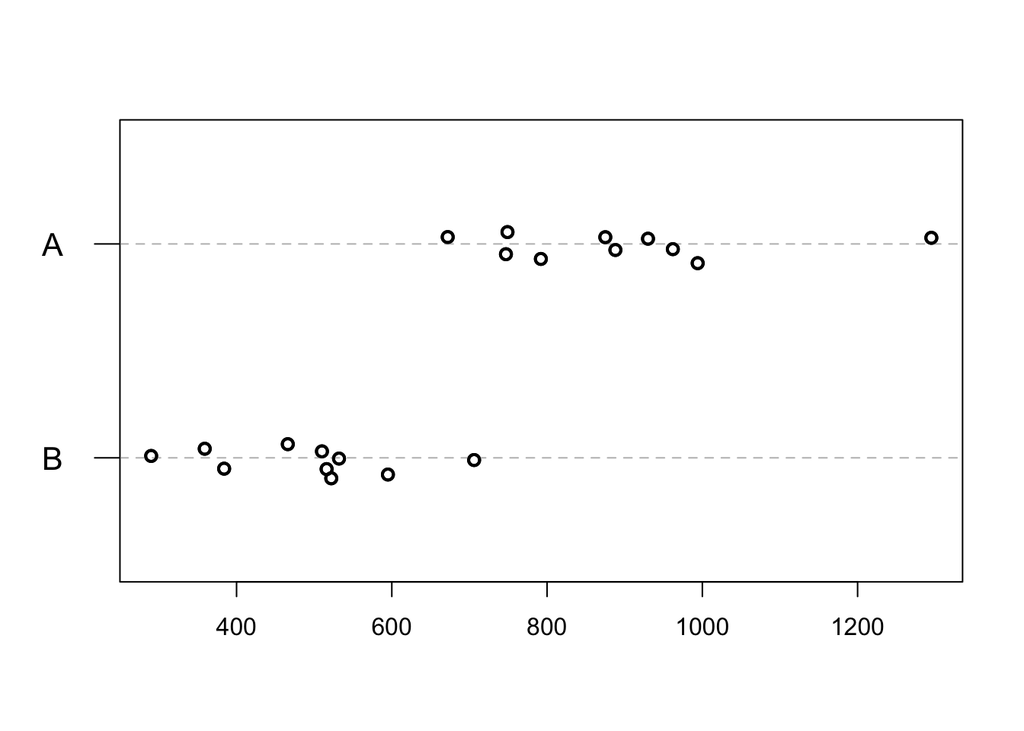

```r
dot.plot(xa,xb, includeCI=FALSE)
```

Plot the data, using the `stripchart` function. Look at the help file to explore what all the arguments do.

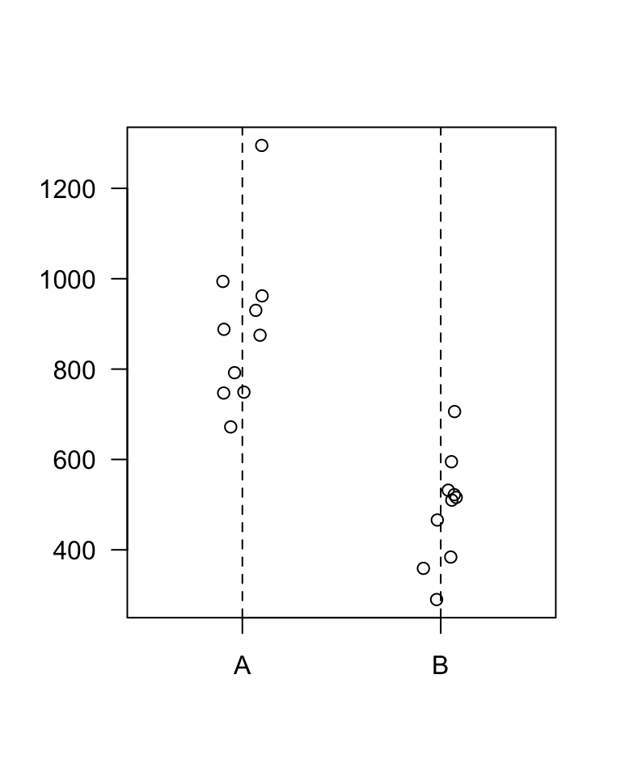

```r
par(las=1)
stripchart(list(xa,xb), method="jitter", pch=1, vertical=TRUE, xlim=c(0.5,2.5), group.names=c("A","B"))
abline(v=1:2,lty=2)
```

The 95% confidence interval for the ratio of the population variances, the pedestrian way.

```r
ratio <- var(xa)/var(xb)
ratio
```

```
## [1] 2.14067
```

```r
na <- length(xa)
na
```

```
## [1] 10
```

```r
nb <- length(xb)
nb
```

```
## [1] 10
```

```r
L <- qf(0.025,na-1,nb-1)
L
```

```
## [1] 0.2483859
```

```r
U <- qf(0.975,na-1,nb-1)
U
```

```
## [1] 4.025994
```

```r
c(ratio/U,ratio/L)
```

```
## [1] 0.5317123 8.6183268
```

The 95% confidence interval for the ratio of the population standard deviations.

```r
sqrt(c(ratio/U,ratio/L))
```

```
## [1] 0.729186 2.935699
```

The built-in function.

```r
var.test(xa,xb)
```

```
##
##  F test to compare two variances
##
## data:  xa and xb
## F = 2.1407, num df = 9, denom df = 9, p-value = 0.2723
## alternative hypothesis: true ratio of variances is not equal to 1
## 95 percent confidence interval:
##  0.5317123 8.6183268
## sample estimates:
## ratio of variances
##            2.14067
```

```r
attributes(var.test(xa,xb))
```

```
## $names
## [1] "statistic"   "parameter"   "p.value"     "conf.int"    "estimate"    "null.value"  "alternative"
## [8] "method"      "data.name"
##
## $class
## [1] "htest"
```

```r
var.test(xa,xb)$estimate
```

```
## ratio of variances
##            2.14067
```

```r
var.test(xa,xb)$p.value
```

```
## [1] 0.2722659
```

```r
var.test(xa,xb)$conf.int
```

```
## [1] 0.5317123 8.6183268
## attr(,"conf.level")
## [1] 0.95
```

```r
sqrt(var.test(xa,xb)$conf.int)
```

```
## [1] 0.729186 2.935699
## attr(,"conf.level")
## [1] 0.95
```

#### Example from class: diets and blood coagulation times

```r
coag <- c(62, 60, 63, 59,
          63, 67, 71, 64, 65, 66,
          68, 66, 71, 67, 68, 68,
          56, 62, 60, 61, 63, 64, 63, 59)
ttt <-  c("A","A","A","A",
          "B","B","B","B","B","B",
          "C","C","C","C","C","C",
          "D","D","D","D","D","D","D","D")
ttt
```

```
##  [1] "A" "A" "A" "A" "B" "B" "B" "B" "B" "B" "C" "C" "C" "C" "C" "C" "D" "D" "D" "D" "D" "D" "D" "D"
```

```r
LETTERS[1:4]
```

```
## [1] "A" "B" "C" "D"
```

```r
ttt <- rep(LETTERS[1:4],c(4,6,6,8))
ttt
```

```
##  [1] "A" "A" "A" "A" "B" "B" "B" "B" "B" "B" "C" "C" "C" "C" "C" "C" "D" "D" "D" "D" "D" "D" "D" "D"
```

Make the treatment “ttt” a factor.

```r
str(ttt)
```

```
##  chr [1:24] "A" "A" "A" "A" "B" "B" "B" "B" "B" "B" "C" "C" "C" "C" "C" "C" "D" "D" "D" "D" "D" "D" "D" ...
```

```r
ttt <- factor(ttt,levels=c("A","B","C","D"))
str(ttt)
```

```
##  Factor w/ 4 levels "A","B","C","D": 1 1 1 1 2 2 2 2 2 2 ...
```

Plot the data. In the `stripchart` function you want to jitter the data points horizontally, vertically, or stack them, since there are identical coagulation times recorded in some of the groups.

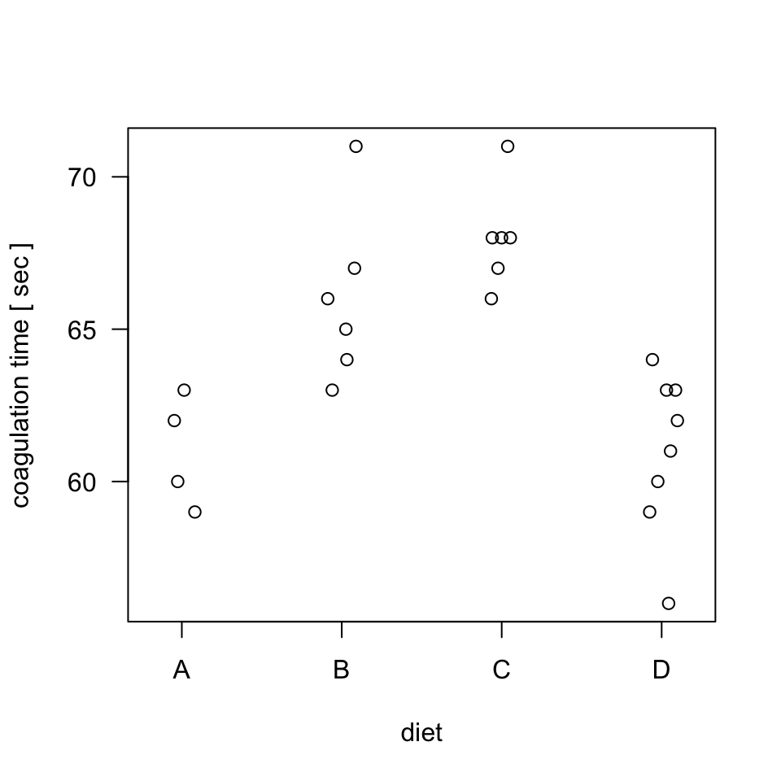

```r
set.seed(1)
par(las=1)
stripchart(coag~ttt, method="jitter", pch=1, vertical=TRUE, xlab="diet", ylab="coagulation time [ sec ]")
```

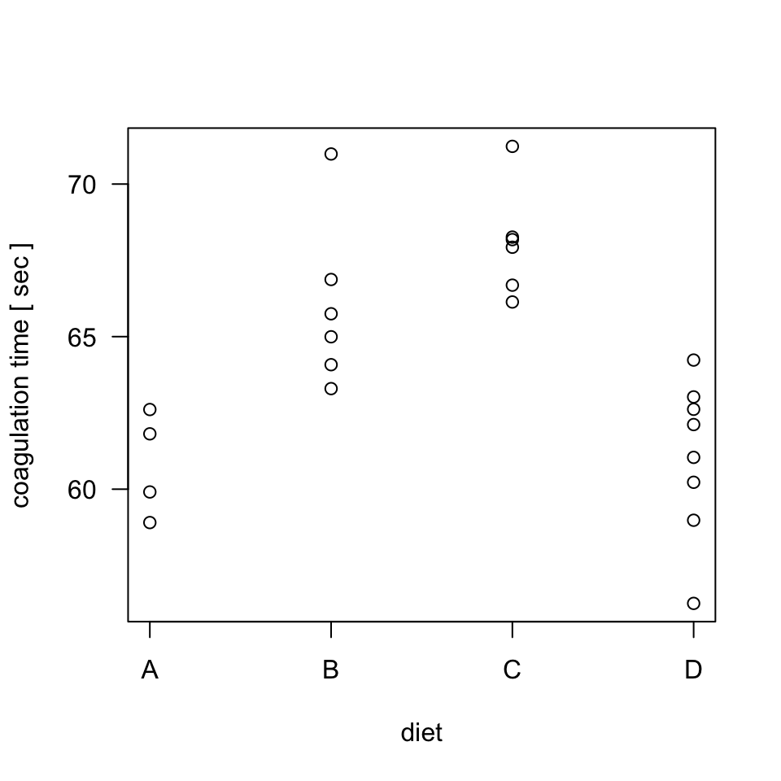

```r
stripchart(jitter(coag,factor=2)~ttt, pch=1, vertical=TRUE, xlab="diet", ylab="coagulation time [ sec ]")
```

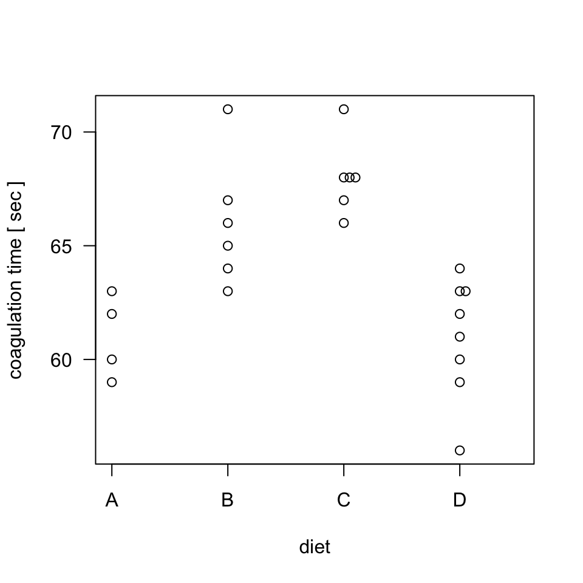

```r
stripchart(coag~ttt, method="stack", pch=1, vertical=TRUE, xlab="diet", ylab="coagulation time [ sec ]")
```

Note: the function `tapply` splits the first vector into groups according to the values in the second vector, and then “applies” the function, here ‘mean’, to each group.

The within-group means.

```r
tapply(coag,ttt,mean)
```

```
##  A  B  C  D
## 61 66 68 61
```

The number of data points per group.

```r
tapply(coag,ttt,length)
```

```
## A B C D
## 4 6 6 8
```

One-way ANOVA, the pedestrain way.

```r
k <- 4
m <- tapply(coag,ttt,mean)
m
```

```
##  A  B  C  D
## 61 66 68 61
```

```r
gm <- mean(coag)
gm
```

```
## [1] 64
```

```r
n <- tapply(coag,ttt,length)
n
```

```
## A B C D
## 4 6 6 8
```

```r
N <- sum(n)
N
```

```
## [1] 24
```

```r
m-gm
```

```
##  A  B  C  D
## -3  2  4 -3
```

```r
SB <- sum(n*(m-gm)^2)
SB
```

```
## [1] 228
```

```r
coag
```

```
##  [1] 62 60 63 59 63 67 71 64 65 66 68 66 71 67 68 68 56 62 60 61 63 64 63 59
```

```r
rep(m,n)
```

```
##  A  A  A  A  B  B  B  B  B  B  C  C  C  C  C  C  D  D  D  D  D  D  D  D
## 61 61 61 61 66 66 66 66 66 66 68 68 68 68 68 68 61 61 61 61 61 61 61 61
```

```r
coag-rep(m,n)
```

```
##  A  A  A  A  B  B  B  B  B  B  C  C  C  C  C  C  D  D  D  D  D  D  D  D
##  1 -1  2 -2 -3  1  5 -2 -1  0  0 -2  3 -1  0  0 -5  1 -1  0  2  3  2 -2
```

```r
SW <- sum((coag-rep(m,n))^2)
SW
```

```
## [1] 112
```

```r
MB <- SB/(k-1)
MB
```

```
## [1] 76
```

```r
MW <- SW/(N-k)
MW
```

```
## [1] 5.6
```

```r
Fstat <- MB/MW
Fstat
```

```
## [1] 13.57143
```

```r
p <- pf(Fstat,k-1,N-k,lower=FALSE)
p
```

```
## [1] 4.658471e-05
```

The built-in function.

```r
aov(coag~ttt)
```

```
## Call:
##    aov(formula = coag ~ ttt)
##
## Terms:
##                 ttt Residuals
## Sum of Squares  228       112
## Deg. of Freedom   3        20
##
## Residual standard error: 2.366432
## Estimated effects may be unbalanced
```

```r
summary(aov(coag~ttt))
```

```
##             Df Sum Sq Mean Sq F value   Pr(>F)
## ttt          3    228    76.0   13.57 4.66e-05 ***
## Residuals   20    112     5.6
## ---
## Signif. codes:  0 '***' 0.001 '**' 0.01 '*' 0.05 '.' 0.1 ' ' 1
```

```r
anova(aov(coag~ttt))
```

```
## Analysis of Variance Table
##
## Response: coag
##           Df Sum Sq Mean Sq F value    Pr(>F)
## ttt        3    228    76.0  13.571 4.658e-05 ***
## Residuals 20    112     5.6
## ---
## Signif. codes:  0 '***' 0.001 '**' 0.01 '*' 0.05 '.' 0.1 ' ' 1
```

#### Example from class: meioses in females and males

The `meiosis` data used in this lecture are available in the SPH.140.615 R package you installed and loaded above.

Reference: Broman et al. (1998) Am J Hum Genet 63:861-869.

The data have three columns: family, female, male. These last two give the total number of crossovers on the 22 autosomes in each of the male and female meioses.

```r
head(meioses)
```

```
##   family female male
## 1    102     28   24
## 2    102     50   22
## 3    102     32   26
## 4    102     35   14
## 5    102     39   20
## 6    102     44   21
```

```r
str(meioses)
```

```
## 'data.frame':    92 obs. of  3 variables:
##  $ family: int  102 102 102 102 102 102 102 102 102 102 ...
##  $ female: int  28 50 32 35 39 44 33 40 28 37 ...
##  $ male  : int  24 22 26 14 20 21 21 22 30 20 ...
```

We need to make the family column a “factor” to get the ANOVA to work properly.

```r
meioses$family <- as.factor(meioses$family)
str(meioses)
```

```
## 'data.frame':    92 obs. of  3 variables:
##  $ family: Factor w/ 8 levels "102","884","1331",..: 1 1 1 1 1 1 1 1 1 1 ...
##  $ female: int  28 50 32 35 39 44 33 40 28 37 ...
##  $ male  : int  24 22 26 14 20 21 21 22 30 20 ...
```

Plot the data for the female meioses, get the within-group means, and add the means to the plot.

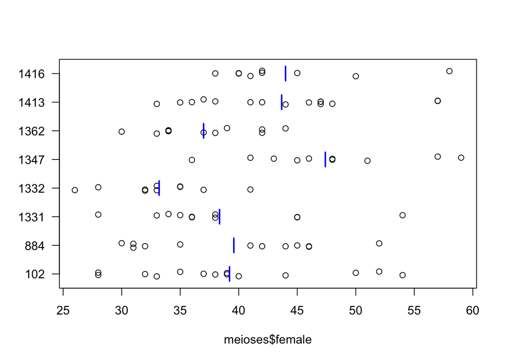

```r
par(las=1)
stripchart(meioses$female~meioses$family,method="jitter",pch=1)
female.me <- tapply(meioses$female,meioses$family,mean)
segments(female.me,(1:8)-0.25,female.me,(1:8)+0.25,lwd=2,col="blue")
```

Same for the male counts.

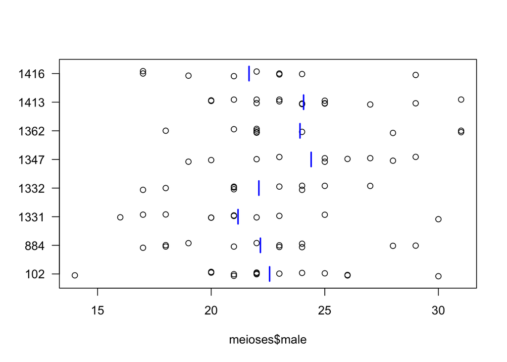

```r
par(las=1)
stripchart(meioses$male~meioses$family,method="jitter",pch=1)
male.me <- tapply(meioses$male,meioses$family,mean)
segments(male.me,(1:8)-0.25,male.me,(1:8)+0.25,lwd=2,col="blue")
```

The ANOVA tables.

```r
out.fem <- aov(female~family,data=meioses)
summary(out.fem)
```

```
##             Df Sum Sq Mean Sq F value   Pr(>F)
## family       7   1485  212.15   4.601 0.000216 ***
## Residuals   84   3873   46.11
## ---
## Signif. codes:  0 '***' 0.001 '**' 0.01 '*' 0.05 '.' 0.1 ' ' 1
```

```r
out.mal <- aov(male~family,data=meioses)
summary(out.mal)
```

```
##             Df Sum Sq Mean Sq F value Pr(>F)
## family       7    114   16.28    1.23  0.296
## Residuals   84   1112   13.24
```

#### Another example

```r
xA <- c(47,48,51,54)
xB <- c(39,44,38,39)
xC <- c(47,49,41,43)
x <- c(xA,xB,xC)
treat <- rep(1:3,rep(4,3))
x
```

```
##  [1] 47 48 51 54 39 44 38 39 47 49 41 43
```

```r
treat
```

```
##  [1] 1 1 1 1 2 2 2 2 3 3 3 3
```

```r
ex <- data.frame(rsp=x,trt=treat)
ex
```

```
##    rsp trt
## 1   47   1
## 2   48   1
## 3   51   1
## 4   54   1
## 5   39   2
## 6   44   2
## 7   38   2
## 8   39   2
## 9   47   3
## 10  49   3
## 11  41   3
## 12  43   3
```

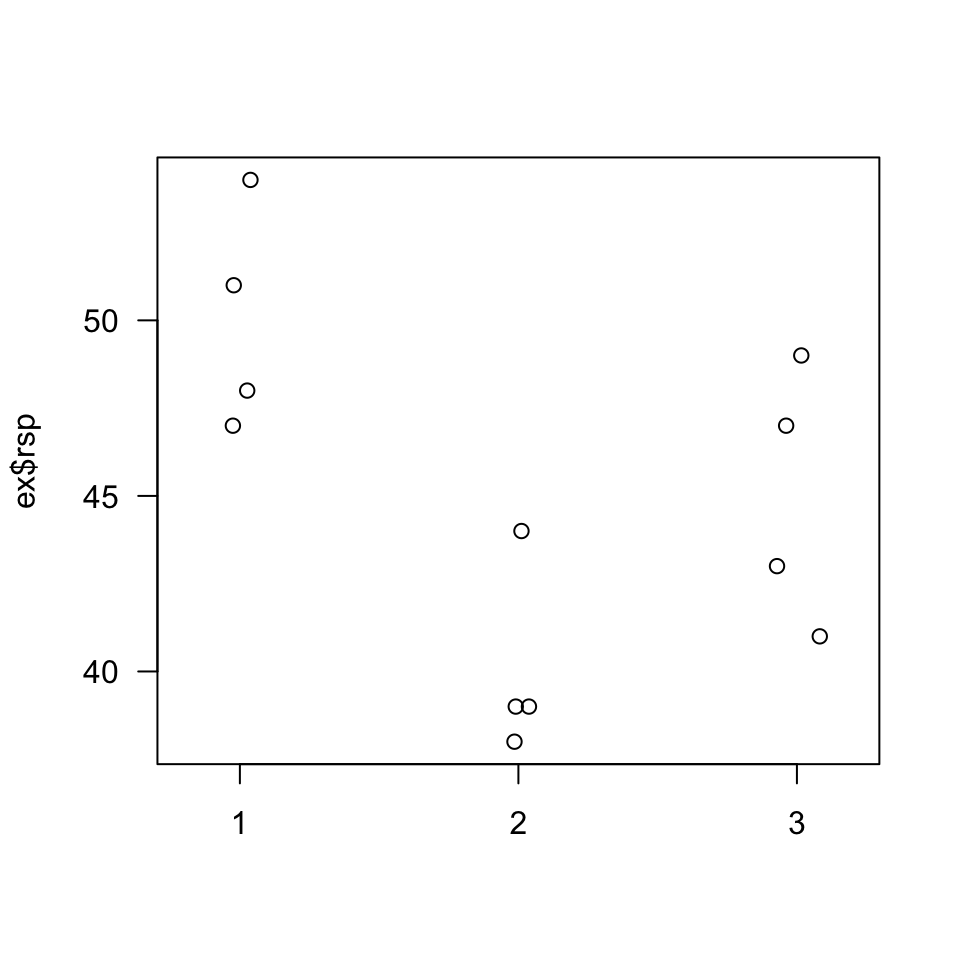

```r
par(las=1)
stripchart(ex$rsp~ex$trt, method="jitter", pch=1, vertical=TRUE)
```

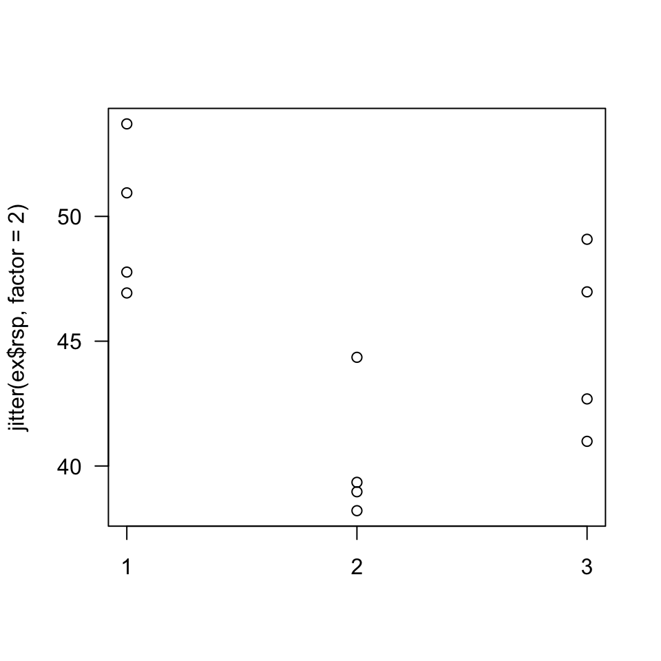

```r
stripchart(jitter(ex$rsp,factor=2)~ex$trt, pch=1, vertical=TRUE)
```

The following is wrong.

```r
aov.out <- aov(rsp~trt,data=ex)
summary(aov.out)
```

```
##             Df Sum Sq Mean Sq F value Pr(>F)
## trt          1     50    50.0   2.066  0.181
## Residuals   10    242    24.2
```

The correct way.

```r
treat <- factor(rep(1:3,rep(4,3)))
ex.c <- data.frame(rsp=x,trt=treat)
aov.out.c <- aov(rsp~trt,data=ex.c)
summary(aov.out.c)
```

```
##             Df Sum Sq Mean Sq F value  Pr(>F)
## trt          2    200  100.00   9.783 0.00553 **
## Residuals    9     92   10.22
## ---
## Signif. codes:  0 '***' 0.001 '**' 0.01 '*' 0.05 '.' 0.1 ' ' 1
```

Compare.

```r
summary(aov.out)
```

```
##             Df Sum Sq Mean Sq F value Pr(>F)
## trt          1     50    50.0   2.066  0.181
## Residuals   10    242    24.2
```

```r
summary(aov.out.c)
```

```
##             Df Sum Sq Mean Sq F value  Pr(>F)
## trt          2    200  100.00   9.783 0.00553 **
## Residuals    9     92   10.22
## ---
## Signif. codes:  0 '***' 0.001 '**' 0.01 '*' 0.05 '.' 0.1 ' ' 1
```

```r
str(ex)
```

```
## 'data.frame':    12 obs. of  2 variables:
##  $ rsp: num  47 48 51 54 39 44 38 39 47 49 ...
##  $ trt: int  1 1 1 1 2 2 2 2 3 3 ...
```

```r
str(ex.c)
```

```
## 'data.frame':    12 obs. of  2 variables:
##  $ rsp: num  47 48 51 54 39 44 38 39 47 49 ...
##  $ trt: Factor w/ 3 levels "1","2","3": 1 1 1 1 2 2 2 2 3 3 ...
```

```r
summary(ex)
```

```
##       rsp             trt
##  Min.   :38.00   Min.   :1
##  1st Qu.:40.50   1st Qu.:1
##  Median :45.50   Median :2
##  Mean   :45.00   Mean   :2
##  3rd Qu.:48.25   3rd Qu.:3
##  Max.   :54.00   Max.   :3
```

```r
summary(ex.c)
```

```
##       rsp        trt
##  Min.   :38.00   1:4
##  1st Qu.:40.50   2:4
##  Median :45.50   3:4
##  Mean   :45.00
##  3rd Qu.:48.25
##  Max.   :54.00
```